# Advanced Python - Reading and plotting data

*by Tobias Andermann*

After covering the numpy library, we will now proceed to working with real data.

### Reading, writing and transforming data with pandas

Pandas is a very useful librayr when it comes to any operations concerning dataframes. First let's load the pandas library. If you don't have it installed yet, install it via your bash command line:

```
pip install pandas
```

```python
import pandas as pd
```

Pandas is really useful for reading and working with data organized in tables. You can read a table into python using pandas as follows (adjust the path to where you downloaded the example data folder). Here we are reading a tab-delimited text file, using the `read_csv()` function.:

```python
data = pd.read_csv('/Users/tobias/GitHub/workshops/advanced_python/input_files/co2_temp.txt',sep='\t')
```

You can view the first lines of the loaded data by using the `.head()` function (instead of printing the complete data on screen, which can be disorienting sometimes):

```python
data.head()
```

|  | year | co2 | temperature |
| --- | --- | --- | --- |
| 0 | 1880 | 289.469999 | 13.81 |
| 1 | 1881 | 289.736999 | 13.89 |
| 2 | 1882 | 290.018999 | 13.89 |
| 3 | 1883 | 290.262999 | 13.80 |
| 4 | 1884 | 290.511999 | 13.71 |

Pandas can even read directly from an excel file (which is super useful, as often biological data is stored in horribly large excel files). You can also deal with quite messy excel files as in the example below. View the file in excel to get an idea of what it looks like. In the command below we read the data by specifying the name of the excel sheet (`sheet_name='ESTIMATES'`,the file contains multiple sheets) and by skipping the first 16 lines of unnecessary information (`header=16`):

```python
data_from_excel = pd.read_excel('/Users/tobias/GitHub/workshops/advanced_python/input_files/world_pop_1950_2015.xlsx',
                                header=16,
                                sheet_name='ESTIMATES')
data_from_excel.head()
```

|  | Index | Variant | Region, subregion, country or area * | Notes | Country code | 1950 | 1951 | 1952 | 1953 | 1954 | ... | 2006 | 2007 | 2008 | 2009 | 2010 | 2011 | 2012 | 2013 | 2014 | 2015 |
| --- | --- | --- | --- | --- | --- | --- | --- | --- | --- | --- | --- | --- | --- | --- | --- | --- | --- | --- | --- | --- | --- |
| 0 | 1 | Estimates | WORLD | NaN | 900 | 2536274.721 | 2583816.786 | 2630584.384 | 2677230.358 | 2724302.468 | ... | 6623847.913 | 6706418.593 | 6789771.253 | 6873741.054 | 6958169.159 | 7043008.586 | 7128176.935 | 7213426.452 | 7298453.033 | 7383008.820 |
| 1 | 2 | Estimates | More developed regions | a | 901 | 814865.069 | 824212.665 | 834074.389 | 844263.515 | 854631.777 | ... | 1215324.559 | 1220392.009 | 1225552.166 | 1230533.857 | 1235142.506 | 1239297.769 | 1243054.571 | 1246519.987 | 1249863.519 | 1253206.546 |
| 2 | 3 | Estimates | Less developed regions | b | 902 | 1721409.652 | 1759604.121 | 1796509.995 | 1832966.843 | 1869670.691 | ... | 5408523.354 | 5486026.584 | 5564219.087 | 5643207.197 | 5723026.653 | 5803710.817 | 5885122.364 | 5966906.465 | 6048589.514 | 6129802.274 |
| 3 | 4 | Estimates | Least developed countries | c | 941 | 195259.056 | 199052.136 | 202904.860 | 206885.020 | 211045.058 | ... | 772488.966 | 790978.141 | 809730.997 | 828953.320 | 848791.962 | 869298.106 | 890423.474 | 912093.996 | 934192.321 | 956631.108 |
| 4 | 5 | Estimates | Less developed regions, excluding least develo... | d | 934 | 1526150.596 | 1560551.985 | 1593605.135 | 1626081.823 | 1658625.633 | ... | 4636034.388 | 4695048.443 | 4754488.090 | 4814253.877 | 4874234.691 | 4934412.711 | 4994698.890 | 5054812.469 | 5114397.193 | 5173171.166 |

5 rows × 71 columns

You can select specific subsets of the data by using row and column indeces or by using the actual column names. Let's for example extract the column with the names of all regions:

```python
data_from_excel['Region, subregion, country or area *']
```

```
0                                                  WORLD
1                                 More developed regions
2                                 Less developed regions
3                              Least developed countries
4      Less developed regions, excluding least develo...
5                Less developed regions, excluding China
6                                  High-income countries
7                                Middle-income countries
8                          Upper-middle-income countries
9                          Lower-middle-income countries
10                                  Low-income countries
11                                    Sub-Saharan Africa
12                                                AFRICA
13                                        Eastern Africa
14                                               Burundi
```

[output cut: 47 more lines]

The selected column in printed as a Pandas Series object. You can easily transform the column values into an array by adding `.values`. This makes it sometimes easier to work with the data, particularly if it's numerical data:

```python
data_from_excel['Region, subregion, country or area *'].values
```

```
array(['WORLD', 'More developed regions', 'Less developed regions',
       'Least developed countries',
       'Less developed regions, excluding least developed countries',
       'Less developed regions, excluding China', 'High-income countries',
       'Middle-income countries', 'Upper-middle-income countries',
       'Lower-middle-income countries', 'Low-income countries',
       'Sub-Saharan Africa', 'AFRICA', 'Eastern Africa', 'Burundi',
       'Comoros', 'Djibouti', 'Eritrea', 'Ethiopia', 'Kenya',
       'Madagascar', 'Malawi', 'Mauritius', 'Mayotte', 'Mozambique',
       'Réunion', 'Rwanda', 'Seychelles', 'Somalia', 'South Sudan',
       'Uganda', 'United Republic of Tanzania', 'Zambia', 'Zimbabwe',
       'Middle Africa', 'Angola', 'Cameroon', 'Central African Republic',
       'Chad', 'Congo', 'Democratic Republic of the Congo',
       'Equatorial Guinea', 'Gabon', 'Sao Tome and Principe',
       'Northern Africa', 'Algeria', 'Egypt', 'Libya', 'Morocco', 'Sudan',
       'Tunisia', 'Western Sahara', 'Southern Africa', 'Botswana',
       'Lesotho', 'Namibia', 'South Africa', 'Swaziland',
       'Western Africa', 'Benin', 'Burkina Faso', 'Cabo Verde',
       "Côte d'Ivoire", 'Gambia', 'Ghana', 'Guinea', 'Guinea-Bissau',
       'Liberia', 'Mali', 'Mauritania', 'Niger', 'Nigeria',
       'Saint Helena', 'Senegal', 'Sierra Leone', 'Togo', 'ASIA',
       'Eastern Asia', 'China', 'China, Hong Kong SAR',
       'China, Macao SAR', 'China, Taiwan Province of China',
       "Dem. People's Republic of Korea", 'Japan', 'Mongolia',
       'Republic of Korea', 'South-Central Asia', 'Central Asia',
       'Kazakhstan', 'Kyrgyzstan', 'Tajikistan', 'Turkmenistan',
       'Uzbekistan', 'Southern Asia', 'Afghanistan', 'Bangladesh',
       'Bhutan', 'India', 'Iran (Islamic Republic of)', 'Maldives',
       'Nepal', 'Pakistan', 'Sri Lanka', 'South-Eastern Asia',
       'Brunei Darussalam', 'Cambodia', 'Indonesia',
       "Lao People's Democratic Republic", 'Malaysia', 'Myanmar',
       'Philippines', 'Singapore', 'Thailand', 'Timor-Leste', 'Viet Nam',
       'Western Asia', 'Armenia', 'Azerbaijan', 'Bahrain', 'Cyprus',
       'Georgia', 'Iraq', 'Israel', 'Jordan', 'Kuwait', 'Lebanon', 'Oman',
       'Qatar', 'Saudi Arabia', 'State of Palestine',
       'Syrian Arab Republic', 'Turkey', 'United Arab Emirates', 'Yemen',
       'EUROPE', 'Eastern Europe', 'Belarus', 'Bulgaria', 'Czechia',
       'Hungary', 'Poland', 'Republic of Moldova', 'Romania',
       'Russian Federation', 'Slovakia', 'Ukraine', 'Northern Europe',
       'Channel Islands', 'Denmark', 'Estonia', 'Faeroe Islands',
```

[output cut: 17 more lines]

```
       'Guatemala', 'Honduras', 'Mexico', 'Nicaragua', 'Panama',
       'South America', 'Argentina', 'Bolivia (Plurinational State of)',
       'Brazil', 'Chile', 'Colombia', 'Ecuador',
       'Falkland Islands (Malvinas)', 'French Guiana', 'Guyana',
       'Paraguay', 'Peru', 'Suriname', 'Uruguay',
       'Venezuela (Bolivarian Republic of)', 'NORTHERN AMERICA',
       'Bermuda', 'Canada', 'Greenland', 'Saint Pierre and Miquelon',
       'United States of America', 'OCEANIA', 'Australia/New Zealand',
       'Australia', 'New Zealand', 'Melanesia', 'Fiji', 'New Caledonia',
       'Papua New Guinea', 'Solomon Islands', 'Vanuatu', 'Micronesia',
       'Guam', 'Kiribati', 'Marshall Islands',
       'Micronesia (Fed. States of)', 'Nauru', 'Northern Mariana Islands',
       'Palau', 'Polynesia', 'American Samoa', 'Cook Islands',
       'French Polynesia', 'Niue', 'Samoa', 'Tokelau', 'Tonga', 'Tuvalu',
       'Wallis and Futuna Islands'], dtype=object)
```

Let's say we want to specifically extract data for a given country or region from the dataframe, for example `AFRICA`. We can do that by telling pandas to select everything where the `'Region, subregion, country or area *'` column has the value `AFRICA`:

```python
africa_data = data_from_excel[data_from_excel['Region, subregion, country or area *']=='AFRICA']
africa_data
```

|  | Index | Variant | Region, subregion, country or area * | Notes | Country code | 1950 | 1951 | 1952 | 1953 | 1954 | ... | 2006 | 2007 | 2008 | 2009 | 2010 | 2011 | 2012 | 2013 | 2014 | 2015 |
| --- | --- | --- | --- | --- | --- | --- | --- | --- | --- | --- | --- | --- | --- | --- | --- | --- | --- | --- | --- | --- | --- |
| 12 | 13 | Estimates | AFRICA | NaN | 903 | 228670.019 | 233277.049 | 238113.121 | 243177.791 | 248471.497 | ... | 948156.166 | 972265.961 | 997144.67 | 1022858.654 | 1049446.344 | 1076933.813 | 1105285.268 | 1134398.192 | 1164129.789 | 1194369.908 |

1 rows × 71 columns

We can accomplish the same by finding the index of the `AFRICA` data row by hand and selecting it that way, using `.iloc[]`. The only difference is that the resulting object in this case is a pandas series, whereas above it is a pandas dataframe (does not make a real difference for most operations).

```python
africa_data = data_from_excel.iloc[12,]
```

If you want to only select the actual population data for Africa, you can do that by providing the column indeces you want ot extract, using the same logic as we did in the numpy tutorial in the array slicing section:

```python
africa_data = data_from_excel.iloc[12,5:]
africa_data.head()
```

```
1950    228670
1951    233277
1952    238113
1953    243178
1954    248471
Name: 12, dtype: object
```

Similarly you can also index the target columns using the other approach of data selection from above:

```python
data_from_excel[data_from_excel['Region, subregion, country or area *']=='AFRICA'].iloc[:,5:]
```

|  | 1950 | 1951 | 1952 | 1953 | 1954 | 1955 | 1956 | 1957 | 1958 | 1959 | ... | 2006 | 2007 | 2008 | 2009 | 2010 | 2011 | 2012 | 2013 | 2014 | 2015 |
| --- | --- | --- | --- | --- | --- | --- | --- | --- | --- | --- | --- | --- | --- | --- | --- | --- | --- | --- | --- | --- | --- |
| 12 | 228670.019 | 233277.049 | 238113.121 | 243177.791 | 248471.497 | 253995.025 | 259750.195 | 265739.281 | 271965.261 | 278431.545 | ... | 948156.166 | 972265.961 | 997144.67 | 1022858.654 | 1049446.344 | 1076933.813 | 1105285.268 | 1134398.192 | 1164129.789 | 1194369.908 |

1 rows × 66 columns

To have best control over the data, let's store the values into numpy arrays, using the `.values` function. Since we are extracting the values of a dataframe, it will return one array row per dataframe row. In this case we only have selected one single row to start with, so in order to just store it as a regular 1D array, we select the first row (the only one) by using the index `[0]`:

```python
africa_pop_values = data_from_excel[data_from_excel['Region, subregion, country or area *']=='AFRICA'].iloc[:,5:].values[0]
```

To remember which value corresponds to which year, let's also store the column names in an array. You can get the column names using the `.columns` function. Then I store the column names in an array, using the `.values` command and transform them into integers using the `.astype()` function:

```python
years_array = data_from_excel.iloc[:,5:].columns.values.astype(int)
years_array
```

```
array([1950, 1951, 1952, 1953, 1954, 1955, 1956, 1957, 1958, 1959, 1960,
       1961, 1962, 1963, 1964, 1965, 1966, 1967, 1968, 1969, 1970, 1971,
       1972, 1973, 1974, 1975, 1976, 1977, 1978, 1979, 1980, 1981, 1982,
       1983, 1984, 1985, 1986, 1987, 1988, 1989, 1990, 1991, 1992, 1993,
       1994, 1995, 1996, 1997, 1998, 1999, 2000, 2001, 2002, 2003, 2004,
       2005, 2006, 2007, 2008, 2009, 2010, 2011, 2012, 2013, 2014, 2015])
```

### Plotting the data

We can plot the data using matplotlib. If not alread installed, install matplotlib by typing `pip install matplotlib` into your bash command line. Then import it like this:

```python
import matplotlib.pyplot as plt
```

Now we can plot the data we extracted. Let's plot years on the x-axis and the human population on the y-axis:

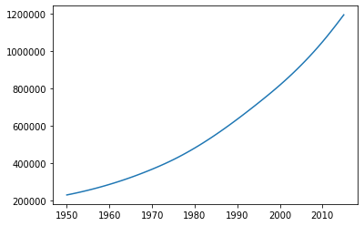

```python
plt.plot(years_array,africa_pop_values)
```

We can improve the looks of the plot a bit by labeling the axes, using the `plt.xlabel()` and `plt.ylabel()` commands:

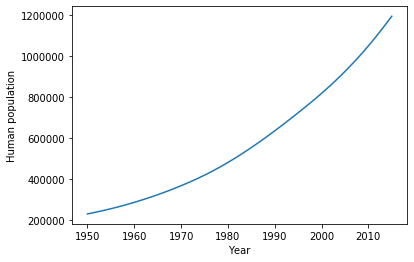

```python
plt.plot(years_array,africa_pop_values);
plt.xlabel('Year');
plt.ylabel('Human population');
```

Let's also define the color of the plotted line, as well as adding a legend. Color can eb defined using the `color=` argument in the plotting command. By giving the plot a label (`label=`) we can plot a legend witht he `plt.legend()` command that automatically pulls the colors and titles of all data in the plot (especially useful when plotting multiple lines):

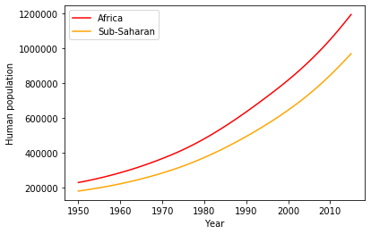

```python
sub_saharan_africa_pop_values = data_from_excel[data_from_excel['Region, subregion, country or area *']=='Sub-Saharan Africa'].iloc[:,5:].values[0]

plt.plot(years_array,africa_pop_values,color='red', label='Africa');
plt.plot(years_array,sub_saharan_africa_pop_values,color='orange', label='Sub-Saharan');
plt.xlabel('Year');
plt.ylabel('Human population');
plt.legend()
```

You can find more plotting options to tweek your plots here: https://matplotlib.org/3.1.1/api/_as_gen/matplotlib.pyplot.plot.html

If you want to store your plot to a pdf file you first have to define a figure instance (`fig = plt.figure()`) and then save it (`fig.savefig()`) after the plotting commands are executed. You can also adjust the size of the figure by providing the `figsize =` setting in the `plt.figure()` command.

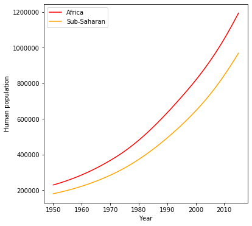

```python
fig = plt.figure(figsize = (6,6))
plt.plot(years_array,africa_pop_values,color='red', label='Africa');
plt.plot(years_array,sub_saharan_africa_pop_values,color='orange', label='Sub-Saharan');
plt.xlabel('Year');
plt.ylabel('Human population');
plt.legend()
fig.savefig('/Users/tobias/GitHub/workshops/advanced_python/output_files/human_pop.pdf',dpi = 500)
```

**TASK:** Plot the human population trends for all continents (or any set of countries/regions you prefer), using the pandas data-selection tools you just learned. You can plot multiple lines into the same plot by just executing multiple plot commands at the same time. You may need to log-transform the population size values in order to properly visualize the trends for all continents in comparison, mainly because Asia has such a large population.